# Properties of OLS Estimators

Natasha Kang

Xiamen University, Chow Institute

May, 2026

## Estimators vs. Estimates

- An **estimate** is a number — the value $\hat\beta_1$ computed from a particular sample.
- An **estimator** is a random variable — a function of the random sample, whose value changes across samples.
- We have discussed the **algebraic** properties of OLS estimates (they hold in any sample).
- Now we study the **statistical** properties of OLS estimators — properties that hold across repeated sampling:
  - **Unbiasedness**: Is the estimator centered on the true parameter?
  - **Variance**: How much does the estimator vary across samples?

## The Gauss-Markov Assumptions: SLR

1. **SLR.1 — Linear in Parameters**: $Y = \beta_0 + \beta_1 X + U$
2. **SLR.2 — Random Sampling**: $\{(X_i, Y_i) : i = 1, \ldots, n\}$ are i.i.d.
3. **SLR.3 — Variation in $X$**: the sample values of $X$ are not all equal
4. **SLR.4 — Zero Conditional Mean**: $E[U \mid X] = 0$
5. **SLR.5 — Homoskedasticity**: $\text{Var}(U \mid X) = \sigma^2$
- SLR.1–SLR.4 are needed for **unbiasedness**.
- SLR.5 is needed for the **variance formula** and the Gauss-Markov theorem.

## Unbiasedness of OLS

**Theorem**: Under SLR.1–SLR.4,

$$E[\hat\beta_0] = \beta_0, \qquad E[\hat\beta_1] = \beta_1$$

*Proof sketch*: Write $\hat\beta_1$ in terms of the population error:

$$\hat\beta_1 = \frac{\sum_{i=1}^n (X_i - \bar{X})(Y_i - \bar{Y})}{\sum_{i=1}^n (X_i - \bar{X})^2} = \beta_1 + \frac{\sum_{i=1}^n (X_i - \bar{X})U_i}{\sum_{i=1}^n (X_i - \bar{X})^2}$$

Take conditional expectation given $X$. By SLR.4, $E[U_i \mid X] = 0$, so $E[\hat\beta_1 \mid X] = \beta_1$. By the law of iterated expectations, $E[\hat\beta_1] = \beta_1$.

## What Unbiasedness Means (and Doesn’t)

*Which of the following are correct interpretations of unbiasedness?*

1. Estimated coefficients will equal the true values.
2. On average, estimated coefficients will equal the true values.
3. In a given sample, estimates may differ considerably from the true values.
4. In a given sample, estimates are close to the true values.
- **Correct**: 2 and 3.
- Unbiasedness is a property of the **procedure**, not of any single estimate.
- A single estimate can be far from the truth — unbiasedness says the errors average out over many samples.

## The Sampling Distribution

*We said $E[\hat\beta_1] = \beta_1$. But expectation over what?*

- The population and $\beta_j$ are fixed — there is nothing random about them.
- Randomness comes from **sampling**: each sample gives different data, hence a different $\hat\beta_j$.
- The **sampling distribution** describes how $\hat\beta_j$ varies across hypothetical repeated samples.
- $E[\hat\beta_1] = \beta_1$ means this distribution is centered on the truth.

## Unbiasedness: Visualized

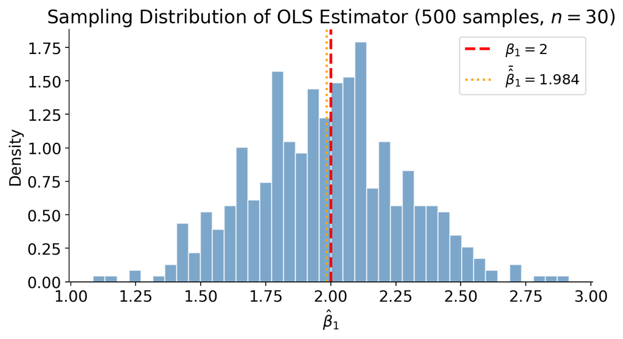

- Each draw from the sampling distribution is one estimate from one sample.
- The distribution is centered on $\beta_1 = 2$ — that is what unbiasedness means.

## What Can Go Wrong: Violating ZCM

- If $\text{Cov}(X, U) \neq 0$, the second term in

$$\hat\beta_1 = \beta_1 + \frac{\sum (X_i - \bar{X})U_i}{\sum (X_i - \bar{X})^2}$$

does **not** vanish in expectation — OLS is **biased**.

- Example: omitting ability from a wage regression on education. If ability is positively correlated with education, $E[\hat\beta_1] > \beta_1$.

## Homoskedasticity

SLR.5 states: $\text{Var}(U \mid X) = \sigma^2$ — the error variance does not depend on $X$.

- **Homoskedasticity**: the spread of $Y$ around the regression line is the same at every value of $X$.
- **Heteroskedasticity**: the spread varies with $X$ — e.g., income variance increases with education.
- Homoskedasticity is needed for the standard variance formulas. If it fails, OLS is still unbiased, but the usual standard errors are wrong.

## Homoskedasticity vs. Heteroskedasticity

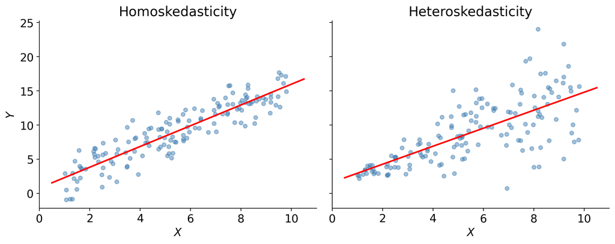

## Variance of OLS Estimators: SLR

**Theorem**: Under SLR.1–SLR.5, conditional on $X$:

$$\text{Var}(\hat\beta_1 \mid X) = \frac{\sigma^2}{\sum_{i=1}^n (X_i - \bar{X})^2}$$

$$\text{Var}(\hat\beta_0 \mid X) = \frac{\sigma^2 \cdot \frac{1}{n}\sum_{i=1}^n X_i^2}{\sum_{i=1}^n (X_i - \bar{X})^2}$$

- Larger error variance $\sigma^2$ → less precise estimates.
- More spread in $X$ → more precise estimates.

## Variance: Visualized

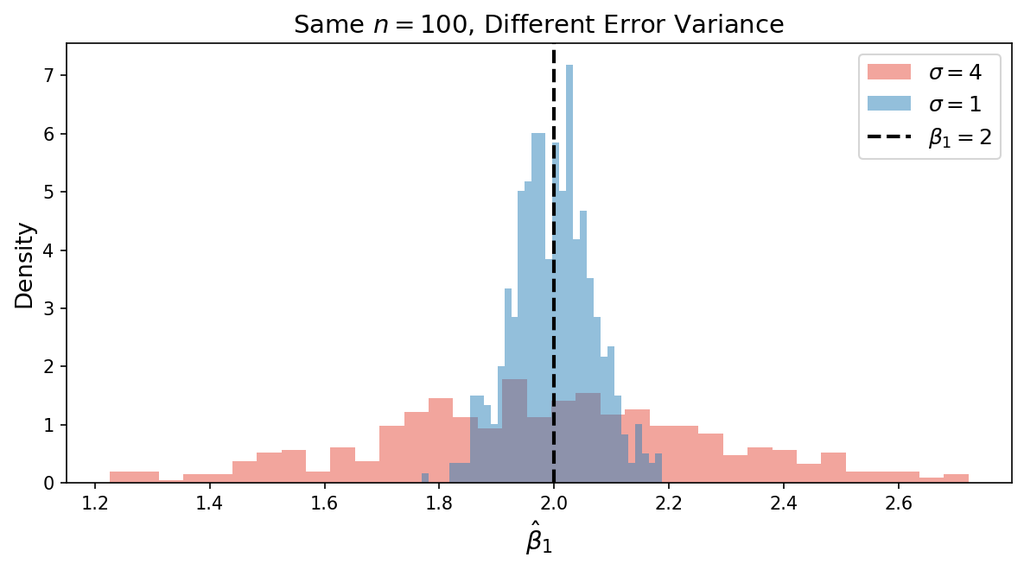

- Both estimators are unbiased — both distributions are centered on $\beta_1 = 2$.
- But the low-variance estimator concentrates more tightly around the truth: any single estimate is likely to be closer.

## Estimating $\sigma^2$: Simple Regression

- We don’t observe $\sigma^2$. If we could observe the errors $U_i$, we’d estimate $\sigma^2$ by $\frac{1}{n}\sum U_i^2$.
- We only observe residuals $\hat{U}_i$, and $\frac{1}{n}\sum \hat{U}_i^2$ is **biased** — the residuals are “too small” on average because OLS minimizes their sum of squares.
- The FOCs impose two restrictions ($\sum \hat{U}_i = 0$ and $\sum X_i \hat{U}_i = 0$), consuming two degrees of freedom.
- The unbiased estimator is:

$$\hat\sigma^2 = \frac{1}{n - 2}\sum_{i=1}^n \hat{U}_i^2$$

## Gauss-Markov Assumptions: MLR

1. **MLR.1 — Linear in Parameters**: $Y = \beta_0 + \beta_1 X_1 + \cdots + \beta_k X_k + U$
2. **MLR.2 — Random Sampling**: $\{(X_{i1}, \ldots, X_{ik}, Y_i) : i = 1, \ldots, n\}$ are i.i.d.
3. **MLR.3 — No Perfect Collinearity**: no exact linear relationships among the regressors
4. **MLR.4 — Zero Conditional Mean**: $E[U \mid X_1, \ldots, X_k] = 0$
5. **MLR.5 — Homoskedasticity**: $\text{Var}(U \mid X_1, \ldots, X_k) = \sigma^2$

## No Perfect Collinearity (MLR.3)

- **Perfect collinearity**: one regressor is an exact linear combination of others — OLS cannot be computed.
- Common violations:
  - Including a constant variable alongside the intercept
  - Including $\text{expendA}$, $\text{expendB}$, and $\text{totexpend} = \text{expendA} + \text{expendB}$
- **Not a violation**: including $X$ and $X^2$. Since $X^2$ is a nonlinear function of $X$, it is not a linear combination.

## Unbiasedness in MLR

**Theorem**: Under MLR.1–MLR.4,

$$E[\hat\beta_j] = \beta_j, \qquad j = 0, 1, \ldots, k$$

The proof follows the same logic as in SLR, extended to multiple regressors.

## Variance of OLS Estimators: MLR

**Theorem**: Under MLR.1–MLR.5, conditional on $X$:

$$\text{Var}(\hat\beta_j \mid X) = \frac{\sigma^2}{\text{SST}_j(1 - R_j^2)}, \qquad j = 1, \ldots, k$$

where $\text{SST}_j = \sum_{i=1}^n (X_{ij} - \bar{X}_j)^2$ and $R_j^2$ is the $R^2$ from regressing $X_j$ on all other regressors.

*Proof*: By FWL, $\hat\beta_j$ is the SLR slope from regressing $Y$ on $\hat{r}_{ij}$ (residuals from $X_j$ on all other $X$’s). Applying the SLR variance formula:

$$\text{Var}(\hat\beta_j \mid X) = \frac{\sigma^2}{\sum_{i=1}^n \hat{r}_{ij}^2} = \frac{\sigma^2}{\text{SST}_j(1 - R_j^2)}$$

where the last equality follows from $\sum \hat{r}_{ij}^2 = \text{SST}_j(1 - R_j^2)$ by definition of $R_j^2$. $\square$

## Understanding $R_j^2$

- $R_j^2$ is **not** the $R^2$ of the main regression of $Y$ on $X$’s.
- $R_j^2$ measures how well $X_j$ is linearly predicted by the **other** regressors.
- If $R_j^2$ is high, most of the variation in $X_j$ is shared with other regressors — little “unique” variation remains to identify $\beta_j$.
- If $R_j^2 = 0$ (uncorrelated regressors), the MLR formula reduces to the SLR formula.

## Three Factors Driving Estimator Precision

$$\text{Var}(\hat\beta_j \mid X) = \frac{\sigma^2}{\text{SST}_j(1 - R_j^2)}$$

1. **Error variance $\sigma^2$**: more noise → less precision. Can reduce by adding relevant controls.
2. **Total variation $\text{SST}_j = n \cdot S_{X_j}^2$**: more variation in $X_j$ → more precision. Increases with sample size.
3. **Collinearity $R_j^2$**: higher $R_j^2$ → less unique variation in $X_j$ → less precision.

## Variance Factors: Visualized

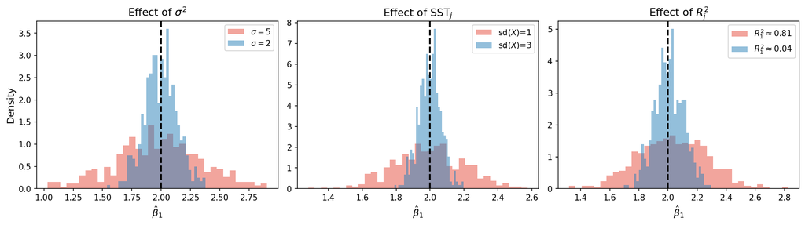

- In each panel, the dashed line marks $\beta_1 = 2$. A tighter distribution means more precise estimation.

## Multicollinearity

- $R_j^2 = 1$: **perfect collinearity** — $\text{Var}(\hat\beta_j) \to \infty$ (violates MLR.3).
- $R_j^2$ close to 1: **multicollinearity** — OLS still works, but estimates are imprecise.
- No clean solution:
  - Dropping correlated variables risks omitted variable bias.
  - Increasing sample size helps (raises $\text{SST}_j$).
- Multicollinearity is a **data problem**, not a model problem — the data lack enough independent variation to distinguish the separate effects.

## Example: Advertising and Sales

$$\text{sales} = \beta_0 + \beta_1 \, \text{tv} + \beta_2 \, \text{online} + \beta_3 \, \text{print} + U$$

- A firm wants to know which advertising channel drives sales.
- But firms that spend more on TV also spend more on online and print — all three scale together.
- $R_j^2$ is high for each channel: most of the variation in one channel’s spending is explained by the others.
- OLS can estimate the **combined** effect precisely, but cannot disentangle the **individual** contributions — standard errors on $\hat\beta_1, \hat\beta_2, \hat\beta_3$ are large.
- This is not a model failure — it reflects a genuine lack of independent variation in the data.

## Estimating $\sigma^2$: MLR

With $k + 1$ parameters estimated, the degrees-of-freedom adjustment gives:

$$\hat\sigma^2 = \frac{1}{n - k - 1}\sum_{i=1}^n \hat{U}_i^2$$

- Under MLR.1–MLR.5, $E[\hat\sigma^2] = \sigma^2$ — unbiased.
- Replacing $\sigma$ with $\hat\sigma = \sqrt{\hat\sigma^2}$ in the variance formula gives the **standard error**:

$$\text{se}(\hat\beta_j) = \frac{\hat\sigma}{\sqrt{\text{SST}_j(1 - R_j^2)}}$$

## The Gauss-Markov Theorem

**Theorem**: Under MLR.1–MLR.5, the OLS estimator is **BLUE** — Best Linear Unbiased Estimator.

- **Unbiased Estimator**: $E[\hat\beta_j] = \beta_j$
- **Linear**: $\hat\beta_j = \sum_{i=1}^n w_{ij} Y_i$ for weights $w_{ij}$ that depend only on $X$
- **Best**: among all linear unbiased estimators, OLS has the **smallest variance**:

$$\text{Var}(\hat\beta_j \mid X) \leq \text{Var}(\ddot\beta_j \mid X)$$

for any other linear unbiased estimator $\ddot\beta_j$.

- Gauss-Markov does **not** say OLS is the best estimator overall — only among those that are both linear and unbiased.

## Misspecified Models

What happens when the model is wrong?

Two forms of misspecification:

- **Over-specification**: including irrelevant variables ($\beta_j = 0$ in the population)
- **Under-specification**: omitting relevant variables ($\beta_j \neq 0$ but excluded)

## Over-Specification

**Population**: $Y = \beta_0 + \beta_1 X_1 + \beta_2 X_2 + U$, with $E[U \mid X_1, X_2, X_3] = 0$

**Estimated model** (adds irrelevant $X_3$, where $\beta_3 = 0$):

$$\hat{Y} = \hat\beta_0 + \hat\beta_1 X_1 + \hat\beta_2 X_2 + \hat\beta_3 X_3$$

*What happens to $\hat\beta_1$ and $\hat\beta_2$? Consider both bias and variance.*

- **Bias?** The Gauss-Markov assumptions still hold — $\hat\beta_1$ and $\hat\beta_2$ remain unbiased.
- **Variance?** Including $X_3$ can increase $R_1^2$ and $R_2^2$, raising $\text{Var}(\hat\beta_1)$ and $\text{Var}(\hat\beta_2)$.
- Over-specification trades **zero bias** for **higher variance**.

## Under-Specification

**Population**: $Y = \beta_0 + \beta_1 X_1 + \beta_2 X_2 + U$, with $E[U \mid X_1, X_2] = 0$

**Estimated model** (omits $X_2$): $Y_i = \tilde\beta_0 + \tilde\beta_1 X_{i1} + V_i$

*What is $V_i$? Does the short regression satisfy ZCM?*

- The error in the short regression is $V_i = \beta_2 X_{i2} + U_i$.
- ZCM requires $E[V \mid X_1] = 0$, i.e.,

$$E[\beta_2 X_2 + U \mid X_1] = \beta_2 \, E[X_2 \mid X_1] + \underbrace{E[U \mid X_1]}_{= 0 \text{ (by LIE)}} = \beta_2 \, E[X_2 \mid X_1]$$

- This is zero only if $\beta_2 = 0$ or $E[X_2 \mid X_1]$ is constant. Otherwise, ZCM fails in the short regression — and from our unbiasedness proof, we know that means $\tilde\beta_1$ is biased.

## Under-Specification: The OVB Formula

*By how much is $\tilde\beta_1$ biased?*

- From Lecture 2b: $\tilde\beta_1 = \hat\beta_1 + \hat\beta_2 \tilde\delta_1$
- Taking expectations:

$$E[\tilde\beta_1 \mid X] = \beta_1 + \underbrace{\beta_2 \tilde\delta_1}_{\text{OVB}}$$

- Biased whenever $\beta_2 \neq 0$ **and** $\tilde\delta_1 \neq 0$.
- Note: this is conditional on $X$; $\tilde\delta_1$ is the *sample* slope of $X_2$ on $X_1$.

## Direction of OVB

The sign of the bias $\beta_2 \times \tilde\delta_1$ depends on:

|  | $\text{Corr}(X_1, X_2) > 0$ | $\text{Corr}(X_1, X_2) < 0$ |
| --- | --- | --- |
| $\beta_2 > 0$ | Positive bias (too large) | Negative bias (too small) |
| $\beta_2 < 0$ | Negative bias | Positive bias |

## OVB Example: Wages and Education

**True model**: $\text{wage} = \beta_0 + \beta_1 \, \text{educ} + \beta_2 \, \text{ability} + U$

**Estimated**: $\text{wage} = \tilde\beta_0 + \tilde\beta_1 \, \text{educ} + V$

*Does $\tilde\beta_1$ overestimate or underestimate the return to education? What do you need to sign the bias?*

- Sign of $\beta_2$? Higher ability → higher wages, so $\beta_2 > 0$.
- Sign of $\text{Corr}(\text{educ}, \text{ability})$? Positive, so $\tilde\delta_1 > 0$.
- Bias $= \beta_2 \tilde\delta_1 > 0$: $\tilde\beta_1$ **overestimates** the return to education.

## OVB Example: Wages and Experience

**True model**: $\text{wage} = \beta_0 + \beta_1 \, \text{educ} + \beta_2 \, \text{exper} + U$

**Estimated**: $\text{wage} = \tilde\beta_0 + \tilde\beta_1 \, \text{educ} + V$

*Same question — does $\tilde\beta_1$ overestimate or underestimate?*

- Sign of $\beta_2$? More experience → higher wages, so $\beta_2 > 0$.
- Sign of $\text{Corr}(\text{educ}, \text{exper})$? Negative (more schooling → later labor market entry), so $\tilde\delta_1 < 0$.
- Bias $= \beta_2 \tilde\delta_1 < 0$: $\tilde\beta_1$ **underestimates** the return to education.

## OVB: Beyond Pairwise Correlations

**True model**: $Y = \beta_0 + \beta_1 X_1 + \beta_2 X_2 + \beta_3 X_3 + U$

**Estimated** (omits $X_3$): $Y_i = \tilde\beta_0 + \tilde\beta_1 X_{i1} + \tilde\beta_2 X_{i2} + V_i$

Suppose $\text{Corr}(X_2, X_3) = 0$. *Is $\tilde\beta_2$ free of OVB?*

- Not necessarily. The OVB in $\tilde\beta_2$ depends on the auxiliary regression of $X_3$ on $(X_1, X_2)$ **jointly** — not on pairwise correlations.
- If $X_1$ is correlated with both $X_2$ and $X_3$, the auxiliary regression can load on $X_2$ even though $X_2$ and $X_3$ are uncorrelated.
- Lesson: in multiple regression, checking pairwise correlations with the omitted variable is not enough.

## Summary

- Under the **Gauss-Markov assumptions** (MLR.1–MLR.5):
  - OLS is **unbiased** (MLR.1–MLR.4)
  - OLS has the **smallest variance** among linear unbiased estimators (Gauss-Markov theorem)
- **Variance** depends on: error variance $\sigma^2$, sample variation in $X_j$, and collinearity $R_j^2$
- **Over-specification**: unbiased but inefficient
- **Under-specification**: biased — OVB formula gives the direction

## What’s Next

**Lecture 3a — Inference**:

- Hypothesis testing and confidence intervals
- The $t$-test and $F$-test
- Inference under finite-sample assumptions